# SEM cookbook

Clay Morrow

2025-11-17

```r
library(tidyverse)
library(lme4)
library(piecewiseSEM)
library(semEff)
```

# 1 Intro

This document outlines the basics of piecewiseSEMs. To render this notebook use the following code (or similar).

```r
rmarkdown::render("infection-modeling/R/rmarkdown/SEM-cookbook.Rmd")
```

# 2 Basic Usage

First, we will load the `keeley` dataset from the `piecewiseSEM` package to use as our example:

```r
# load example data
data("keeley", package = "piecewiseSEM")

# scale and center all columns
keeley_scaled <- keeley %>% tibble() %>%
  mutate(across(c(everything()), ~as.vector(scale(.x))))
```

## 2.1 Initial Fit

Next we’ll fit the component models that will comprise our SEM. These can be many kinds of model fit objects (`lm`, `glm`, `lme4`, `glmmTMB`, etc.). The important things to keep in mind here are that each model represents all the *direct* paths into a response variable and that **there can be no loops** in the model (i.e., if Y is a response of X, then no direct or indirect paths from Y can go back to X). In the case of our example SEM, we will fit 3 models: 1) post-fire species richness dependent on ground cover, 2) ground cover dependent on fire severity, and 3) fire severity dependent upon pre-fire stand age. For this example, we’ll just use simple linear regressions.

```r
# Top level: richness affected by plant cover
rich_mod <- lm(rich ~ cover, data = keeley)

# middle level: plant cover affected by fire severity
cover_mod <- lm(cover ~ firesev, data = keeley)

# bottom level: fire severity affected by stand age prior to fire
fire_mod <- lm(firesev ~ age, data = keeley)
```

Next we will combine these component models into the SEM, using the `psem` function. Then we will actually perform the fit using the `summary.psem` method:

```r
# specify SEM
rich_psem <- psem(rich_mod, cover_mod, fire_mod, data = keeley)

# fit the SEM
rich_fit <- summary(rich_psem, .progressBar = FALSE)
```

```r
rich_fit$dTable # %>%
```

```
##         Independ.Claim Test.Type DF Crit.Value P.Value
## 1    cover ~ age + ...      coef 87    -1.8018  0.0750
## 2     rich ~ age + ...      coef 87    -2.0146  0.0470 *
## 3 rich ~ firesev + ...      coef 86    -1.9546  0.0539
```

```r
  # knitr::kable(
  #   digits = 3,
  #   caption = "D-separated independence claims"
  # )
caption = paste()
```

## 2.2 Update fit

To do so, we can update our component models with the new variables:

```r
# add age and firesev to rich mod
new_rich <- update(rich_mod, . ~ . + age)

# updated SEM spec
new_psem <- psem(new_rich, cover_mod, fire_mod, data = keeley)

# updated SEM spec
new_rich_fit <- summary(new_psem, .progressBar = FALSE)
```

```r
new_rich_fit$dTable #%>%
```

```
##         Independ.Claim Test.Type DF Crit.Value P.Value
## 1    cover ~ age + ...      coef 87    -1.8018  0.0750
## 2 rich ~ firesev + ...      coef 86    -1.9546  0.0539
```

```r
  # knitr::kable(
  #   digits = 3,
  #   caption = "Second d-sep table"
  # )
```

Now that we have an updated SEM, let’s check its overall fit. The `piecewiseSEM` packages provides two goodness of fit tests Fischer’s C test and Chi-squared test. Both test if the SEM is *different from an optimal model* (i.e., one that describes all variation in the data). However, this means that well-fitting models should have p-values *greater* than 0.05 (indicating that they are not different; [source link](https://jslefche.github.io/sem_book/local-estimation.html#)). Since both of our goodness-of-fit p-values are less than .05, we can conclude that the overall fit is relatively poor. Our next steps would be to try and find a model that better fits the data (add new variables, change path orders, etc) but for the simplicity of this example, we will proceed with the model as is.

```r
## Overall tests of model fit (explains variation in the full dataset)
new_rich_fit$Cstat %>%
  bind_rows(new_rich_fit$ChiSq) %>%
  mutate(
    stat = if_else(!is.na(Chisq), "Chisq", "Fisher.C"),
    val = if_else(!is.na(Chisq), Chisq, Fisher.C)
  ) %>%
  select(stat, val, df, P.Value)
```

```
##       stat    val df P.Value
## 1 Fisher.C 11.022  4   0.026
## 2    Chisq  7.209  2   0.027
```

Additionally, we can look at the fits of the component models. The below table shows that each component model has a reasonable $R^2$ value:

```r
new_rich_fit$R2
```

```
##   Response   family     link method R.squared
## 1     rich gaussian identity   none      0.15
## 2    cover gaussian identity   none      0.19
## 3  firesev gaussian identity   none      0.21
```

Note that in some instances, scaling and centering the data can sometimes help with model fitting if the variables are on vastly different scales. But that is not the case for this dataset:

```r
tmp <- psem(
  new_rich %>% update(. ~ ., data = keeley_scaled),
  cover_mod %>% update(. ~ ., data = keeley_scaled),
  fire_mod %>% update(. ~ ., data = keeley_scaled),
  data = keeley_scaled
)
smry <- summary(tmp, .progressBar = FALSE)
smry$Cstat %>%
  bind_rows(smry$ChiSq) %>%
  mutate(
    stat = if_else(!is.na(Chisq), "Chisq", "Fisher.C"),
    val = if_else(!is.na(Chisq), Chisq, Fisher.C)
  ) %>%
  select(stat, val, df, P.Value)
```

```
##       stat    val df P.Value
## 1 Fisher.C 11.022  4   0.026
## 2    Chisq  7.209  2   0.027
```

## 2.3 Model coefficients

```r
new_rich_fit$coefficients #%>%
```

```
##   Response Predictor Estimate Std.Error DF Crit.Value P.Value
## 1     rich     cover  12.1212    5.0309 87     2.4093  0.0181
## 2     rich       age  -0.2559    0.1270 87    -2.0146  0.0470
## 3    cover   firesev  -0.0839    0.0184 88    -4.5594  0.0000
## 4  firesev       age   0.0597    0.0125 88     4.7781  0.0000
##   Std.Estimate
## 1       0.2546   *
## 2      -0.2129   *
## 3      -0.4371 ***
## 4       0.4539 ***
```

```r
  # data.frame() %>%
  # knitr::kable(
  #   digits = 2,
  #   col.names = c(
  #     "Resp.", "Pred.", "Coef. Est.", "SE", "DF", "Crit", "P",
  #     "Std. Effect", "Sig."
  #   ),
  #   caption = paste(
  #     "SEM coefficient table: Response variable, Predictor variable",
  #     "Regression coefficient, Standard Error, Degrees of freedom,",
  #     "Critical value, P-value, Standardized effect size, and significance",
  #     "stars."
  #   )
  # )
```

And we can plot a simple version of the SEM using the `DiagrammeR` package:

```r
library(DiagrammeR)

# copy data
path_tab <- new_rich_fit$coefficients %>%
  data.frame()

# build table of nodes containing a node name and numeric ID
nodes_tab <- tibble(
  name = unique(c(path_tab$Response, path_tab$Predictor))
) %>%
  mutate(id = row_number())

# add some plotting aesthetics to the path table (optional)
path_tab <- path_tab %>%
  mutate(
    ## width of arrows proportional to effect size
    penwidth = scales::rescale(Std.Estimate, to = c(1, 5)),
    ## color of arrows by direction
    color = if_else(Std.Estimate <= 0, "red", "blue"),
    ## linetype of the arrow by significance
    style = if_else(P.Value <= 0.1, "solid", "dashed"),
    ## edge labels (near center)
    label = round(Std.Estimate, 2)
  )

# create the graph
sem_graph <- create_graph(attr_theme = "bt") %>%
  add_nodes_from_table(nodes_tab, label_col = "name") %>%
  add_edges_from_table(
    path_tab, from_col = "Predictor", to_col = "Response",
    from_to_map = "label"
  ) %>%
  ## set some universal node attributes
  set_node_attrs("color", "black") %>%
  set_node_attrs("fillcolor", "white")

# render the graph
render_graph(sem_graph)
```

[interactive chart not shown]

## 2.4 Cumulative effects

The following code calculates all the indirect and total effects and then plots them:

```r
## function to get all coefficients along a path
get_coefs_along_path <- function(p, edges, nodes){
  # early return for a missing path
  if (length(p) == 1 | all(is.na(p))){
    return(NA)
  }
  # convert the path numbers into names
  v <- nodes$name[p]
  # direct effect
  if (length(p) == 2) {
    ## return the direct effect
    edges %>%
      filter(Predictor == v[1], Response == v[2]) %>%
      pull(Std.Estimate) %>% return()
  }
  # indirect effects
  ## join into a lag table
  tab <- cbind(from = head(v, -1), to = tail(v, -1))
  ## go through all the rows of the table and find the matching coefficient
  apply(
    tab, 1, function(x) {
      pull(filter(edges, Predictor == x[1], Response == x[2]), Std.Estimate)
    }
  ) %>% return()
}
```

```r
# build a table to fill
breakdown <- expand_grid(
  Response = unique(path_tab$Response), Predictor = unique(path_tab$Predictor)
) %>%
  ## response can't equal predictor
  filter(Response != Predictor) %>%
  ## add IDs for response and predictors
  mutate(
    resp_ID = nodes_tab$id[match(Response, nodes_tab$name)],
    pred_ID = nodes_tab$id[match(Predictor, nodes_tab$name)]
  ) %>%
  ## add direct effects and associated P-value
  left_join(
    path_tab %>%
      select(Response, Predictor, direct_P = P.Value, direct = Std.Estimate),
    by = c("Response", "Predictor")
  ) %>%
  ## prepare to loop through each row
  rowwise() %>%
  ## perform operations to each row...
  mutate(
    ## get a list of all possible paths from the predictor to the response
    all_paths = list(unique(get_paths(sem_graph, from = pred_ID, to = resp_ID))),
    ## get a list of coefficients along those paths
    all_coefs = list(
      lapply(all_paths, function(x)get_coefs_along_path(x, path_tab, nodes_tab))
    ),
    ## multiply the coefficients along a path
    coef_prods = list(lapply(all_coefs, prod)),
    ## get the total effect, by adding up the products
    total = sum(unlist(coef_prods), na.rm = TRUE),
    ## calculate indirect effects by subtracting the direct effects from the total
    indirect = if_else(!is.na(direct), total - direct, total - 0)
  ) %>%
  ## remove the rowwise grouping
  ungroup()
```

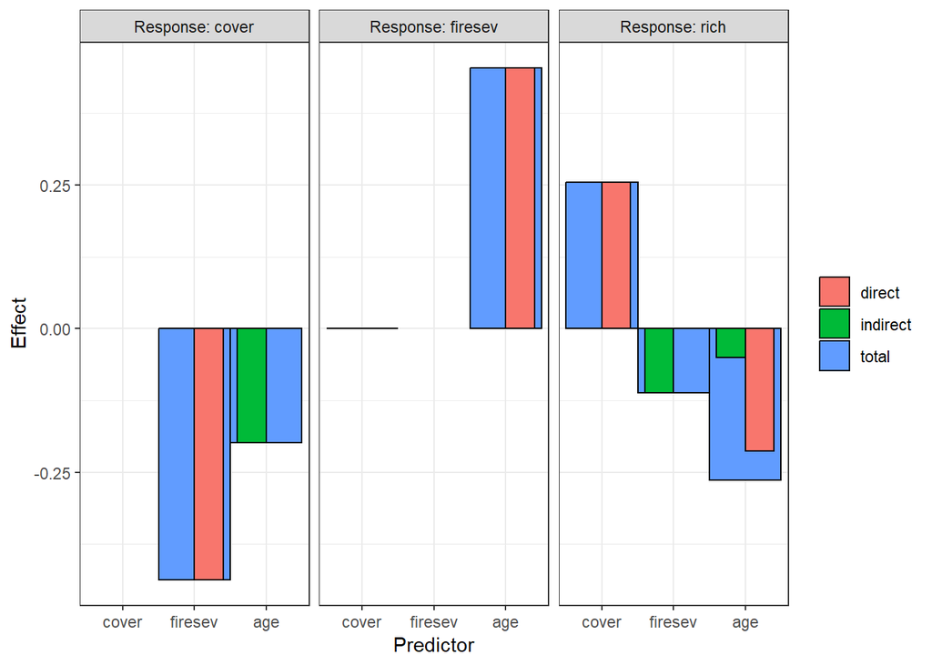

```r
# plot the breakdown
breakdown %>%
  select(Response, Predictor, direct_P, direct, indirect, total) %>%
  mutate(
    Resposne = factor(Response, levels = nodes_tab$name),
    Predictor = factor(Predictor, levels = nodes_tab$name)
  ) %>%
  ggplot(aes(x = Predictor)) +
  facet_wrap(~Response, labeller = label_both) +
  geom_col(aes(y = total, fill = "total"), col = "black", width = 1) +
  geom_col(
    aes(y = direct, fill = "direct"),
    col = "black", width = 0.4, position = position_nudge(x = 0.2)
  ) +
  geom_col(
    aes(y = indirect, fill = "indirect"),
    col = "black", width = 0.4, position = position_nudge(x = -0.2)
  ) +
  theme_bw() +
  labs(x = "Predictor", y = "Effect", fill = NULL)
```

# 3 semEff

The `semEff` package can be used to obtain bootstrapped confidence intervals, and/or to automatically extract indirect and total effects:

```r
# the SEM as a list of models
modlist <- list(richness = new_rich, cover = cover_mod, firesev = fire_mod)

# boot strap the model (with 10 iterations), using default settings
sem_boot <- bootEff(modlist, R = 10)
```

```r
# calculate the effects from the bootsrapped model
sem_effs <- semEff(sem_boot, ci.conf = 0.90)

# print a summary of all effects
summary(sem_effs)
```

```
##
## SEM direct, summed indirect, total, and mediator effects:
```

```
##
## Response 'richness' (1/3):
```

```
##                       Effect     Bias   Std. Err.   Lower CI Upper CI
##                       ------   ------   ---------   -------- --------
##  DIRECT:    age     | -0.199 | -0.015 |     0.108 |   -0.383   -0.077 |
##             cover   |  0.238 | -0.035 |     0.106 |    0.059    0.366 |
##                     |        |        |           |                   |
##  INDIRECT:  age     | -0.047 |  0.008 |     0.024 |   -0.075   -0.024 |
##             firesev | -0.104 |  0.016 |     0.056 |   -0.180   -0.058 |
##                     |        |        |           |                   |
##  TOTAL:     age     | -0.247 | -0.007 |     0.091 |   -0.394   -0.140 |
##             cover   |  0.238 | -0.035 |     0.106 |    0.059    0.366 |
##             firesev | -0.104 |  0.016 |     0.056 |   -0.180   -0.058 |
##                     |        |        |           |                   |
##  MEDIATORS: cover   | -0.152 |  0.024 |     0.079 |   -0.250   -0.082 |
##             firesev | -0.047 |  0.008 |     0.024 |   -0.075   -0.024 |
##
##
##  *
##  *
##
##  *
##  *
##
##  *
##  *
##  *
##
##  *
##  *
```

```
##
## Response 'cover' (2/3):
```

```
##                       Effect     Bias   Std. Err.   Lower CI Upper CI
##                       ------   ------   ---------   -------- --------
##  DIRECT:    firesev | -0.437 |  0.006 |     0.095 |   -0.549   -0.278 |
##                     |        |        |           |                   |
##  INDIRECT:  age     | -0.198 | -0.004 |     0.069 |   -0.334   -0.114 |
##                     |        |        |           |                   |
##  TOTAL:     age     | -0.198 | -0.004 |     0.069 |   -0.334   -0.114 |
##             firesev | -0.437 |  0.006 |     0.095 |   -0.549   -0.278 |
##                     |        |        |           |                   |
##  MEDIATORS: firesev | -0.198 | -0.004 |     0.069 |   -0.334   -0.114 |
##
##
##  *
##
##  *
##
##  *
##  *
##
##  *
```

```
##
## Response 'firesev' (3/3):
```

```
##                   Effect    Bias   Std. Err.   Lower CI Upper CI
##                   ------   -----   ---------   -------- --------
##  DIRECT:    age |  0.454 | 0.005 |     0.076 |    0.373    0.591 | *
##                 |        |       |           |                   |
##  INDIRECT:  -   |      - |     - |         - |        -        - |
##                 |        |       |           |                   |
##  TOTAL:     age |  0.454 | 0.005 |     0.076 |    0.373    0.591 | *
##                 |        |       |           |                   |
##  MEDIATORS: -   |      - |     - |         - |        -        - |
```

```r
# just extract indirect effects
getIndEff(sem_effs, type = "orig")
```

```
## $richness
##   (Intercept)           age       firesev
##  1.411146e-15 -4.730230e-02 -1.042210e-01
##
## $cover
##   (Intercept)           age
## -1.749845e-15 -1.984003e-01
##
## $firesev
## [1] NA
```

`getDirEff` and `getMedEff` can also be used to extract direct and mediator effects, respectively.

## 3.1 TODO:

- look into mediators
- binomial response / categorical predictors
- work through example together?